# Statistics2, lab week 2: repeated measures ANOVA

J.F.P. (Richard) Scholtens s2956586

May 3th, 2018

## 1. Load data and libraries

The data is given in a format similar to that of file dialect_change_1.csv in the lecture and we need it in a format similar to dialect_change2.csv.

We load the data and create two factor variables, one for the groups and another one for the subjects.

```r
library(car)
library(ez)
RT <- c(461,245,846,976,567,318,567,689,432,658,478,571,578,769,389,518,
        789,368,901,948,890,431,489,543,937,698,498,389,486,777,446,324,
        478,336,753,653,639,302,371,782,480,352,447,434,307,543,787,349,
        646,564,827,824,987,357,598,334,789,599,955,578,778,659,680,448)
mygroups = c("SR_ANP","OR_ANP","SR_INP","OR_INP")
(mysubjects <- seq(16))
```

```
##  [1]  1  2  3  4  5  6  7  8  9 10 11 12 13 14 15 16
```

```r
#your code here, create a sequence of numbers from 1 to 16. Hint: use function seq()

# each group is repeated 16 times
# vector subjects has less elements (16) than RT (64), therefore it will be repeated 4 times
mydata <- data.frame(RT, rep(mygroups, each=16), mysubjects)
colnames(mydata) <- c("RT", "Group", "Subj") # rename to more meaningful names
mydata$Subj <- as.factor(mysubjects)#your code here # we need Subj to be a factor for the analyses below, and it wasn't by default. You can check with str(mydata). Make it a factor using function as.factor()
str(mydata)
```

```
## 'data.frame':    64 obs. of  3 variables:
##  $ RT   : num  461 245 846 976 567 318 567 689 432 658 ...
##  $ Group: Factor w/ 4 levels "OR_ANP","OR_INP",..: 3 3 3 3 3 3 3 3 3 3 ...
##  $ Subj : Factor w/ 16 levels "1","2","3","4",..: 1 2 3 4 5 6 7 8 9 10 ...
```

## 2. Boxplots

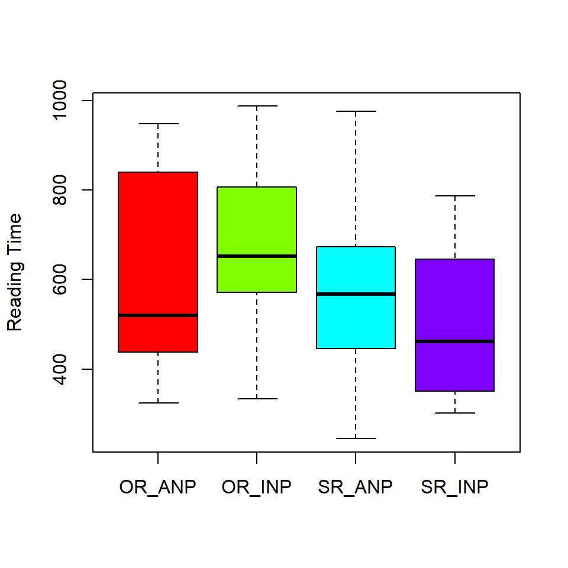

```r
boxplot(mydata$RT ~ mydata$Group, ylab = "Reading Time", col=rainbow(4))
```

I think the OR_INP group has the highest mean of al groups.

I also think the medians differ significantly from eachother.

## 3. Hypotheses

$H_0$ = There is no difference between the reading time of the four sentences: “SR_ANP, OR_ANP, SR_INP, OR_INP”.

$H_a$ = There is a difference between the reading time of the four sentences: “SR_ANP, OR_ANP, SR_INP, OR_INP”.

$\mu$ 1 = SR_ANP

$\mu$ 2 = OR_ANP

$\mu$ 3 = SR_INP

$\mu$ 4 = OR_INP

$H_0$ = $\mu$ 1 = $\mu$ 2 = $\mu$ 3 = $\mu$ 4

$H_a$ = Not all of the $\mu$i are equal

## 4. Normality

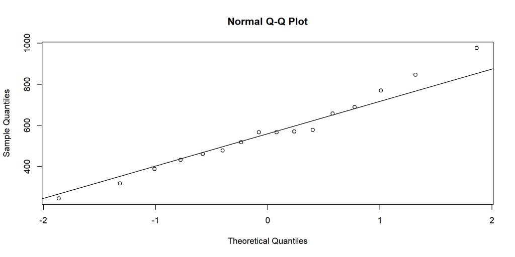

```r
aov <- aov(mydata$RT ~ mydata$Group)

qqnorm(mydata$RT[mydata$Group == 'SR_ANP'])
qqline(mydata$RT[mydata$Group == 'SR_ANP'])
```

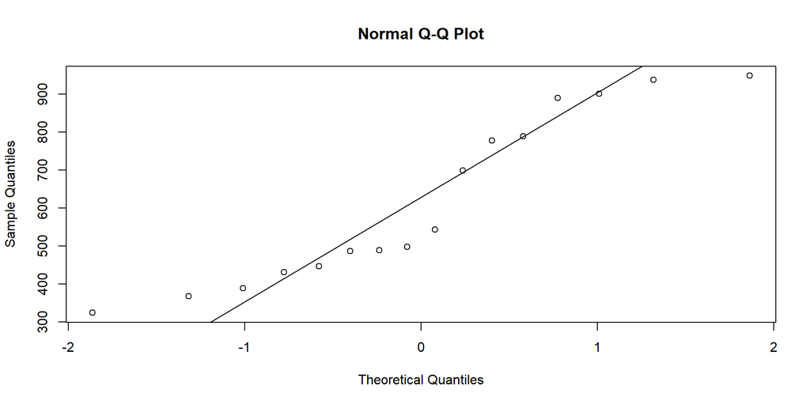

```r
qqnorm(mydata$RT[mydata$Group == 'OR_ANP'])
qqline(mydata$RT[mydata$Group == 'OR_ANP'])
```

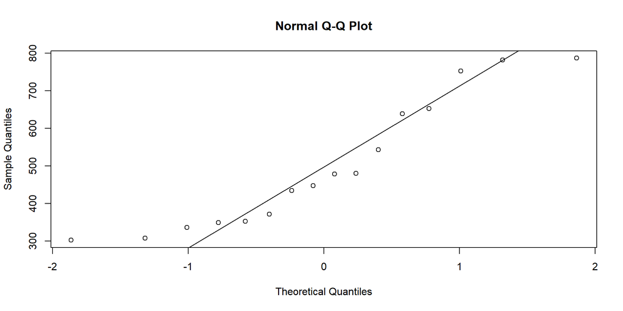

```r
qqnorm(mydata$RT[mydata$Group == 'SR_INP'])
qqline(mydata$RT[mydata$Group == 'SR_INP'])
```

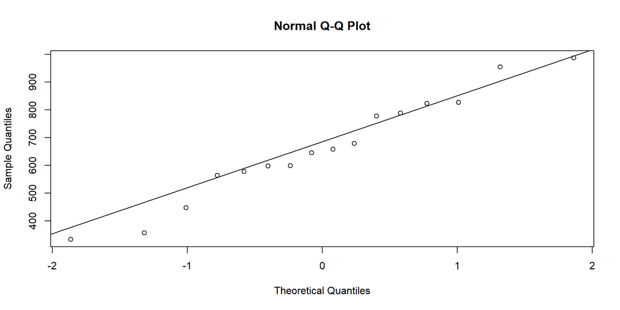

```r
qqnorm(mydata$RT[mydata$Group == 'OR_INP'])
qqline(mydata$RT[mydata$Group == 'OR_INP'])
```

```r
aggregate(mydata$RT ~ mydata$Group, data=mydata, function(x) shapiro.test(x)$p.value)
```

```
##   mydata$Group  mydata$RT
## 1       OR_ANP 0.04878843
## 2       OR_INP 0.78201004
## 3       SR_ANP 0.93644370
## 4       SR_INP 0.05377226
```

$H-0$ = Each group follows normal distribution.

$H-a$ = Each group doesn’t follow normal distribution.

$\alpha$ = 0.05

Shapiro P-value

OR_ANP 0.04878843

OR_INP 0.78201004

SR_ANP 0.93644370

SR_INP 0.05377226

## 5. Variance

```r
leveneTest(aov)
```

```
## Levene's Test for Homogeneity of Variance (center = median)
##       Df F value Pr(>F)
## group  3  0.6366 0.5944
##       60
```

$H-0$ = The variance in the different groups are equal.

$H-a$ = The variance in the different groups are not equal.

$\alpha$ = 0.05

P-value = 0.5944

The p-value is above the significance level. Therefor we do not reject $H-0$. This means all groups are homogeneous.

## 6. 1-way Anova

```r
summary(aov)
```

```
##              Df  Sum Sq Mean Sq F value Pr(>F)
## mydata$Group  3  237369   79123   2.081  0.112
## Residuals    60 2281409   38023
```

```r
summary(lm(formula = mydata$RT ~ mydata$Group, data = mydata))
```

```
##
## Call:
## lm(formula = mydata$RT ~ mydata$Group, data = mydata)
##
## Residuals:
##     Min      1Q  Median      3Q     Max
## -329.94 -137.98  -21.81  153.48  409.63
##
## Coefficients:
##                    Estimate Std. Error t value Pr(>|t|)
## (Intercept)          619.62      48.75  12.711   <2e-16 ***
## mydata$GroupOR_INP    44.31      68.94   0.643    0.523
## mydata$GroupSR_ANP   -53.25      68.94  -0.772    0.443
## mydata$GroupSR_INP  -118.81      68.94  -1.723    0.090 .
## ---
## Signif. codes:  0 '***' 0.001 '**' 0.01 '*' 0.05 '.' 0.1 ' ' 1
##
## Residual standard error: 195 on 60 degrees of freedom
## Multiple R-squared:  0.09424,    Adjusted R-squared:  0.04895
## F-statistic: 2.081 on 3 and 60 DF,  p-value: 0.1122
```

$H_0$ = There is no difference between the reading time of the four sentences: “SR_ANP, OR_ANP, SR_INP, OR_INP”.

$H_a$ = There is a difference between the reading time of the four sentences: “SR_ANP, OR_ANP, SR_INP, OR_INP”.

$\alpha$ = 0.05

p-level = 0.112

The p-level is higher than the significance level of 0.05. Therefor we cannot reject $H_0$.

This means there is no difference between the reading times in the groups.

## 7. Repeated Measures Anova

```r
(summary(rep.aov <- aov(RT~Group + Error(Subj/Group), data = mydata)))
```

```
##
## Error: Subj
##           Df  Sum Sq Mean Sq F value Pr(>F)
## Residuals 15 1306410   87094
##
## Error: Subj:Group
##           Df Sum Sq Mean Sq F value Pr(>F)
## Group      3 237369   79123   3.652 0.0193 *
## Residuals 45 974999   21667
## ---
## Signif. codes:  0 '***' 0.001 '**' 0.01 '*' 0.05 '.' 0.1 ' ' 1
```

```r
(repeated.aov <-  ezANOVA(data = mydata, dv = RT, wid = Subj, within = Group,
detailed = TRUE))$ANOVA
```

```
##        Effect DFn DFd        SSn       SSd          F            p p<.05
## 1 (Intercept)   1  15 22104102.2 1306409.8 253.795973 8.272671e-11     *
## 2       Group   3  45   237368.9  974999.1   3.651832 1.933615e-02     *
##          ges
## 1 0.90644408
## 2 0.09423971
```

$H_0$ = There is no difference between the reading time of the four sentences: “SR_ANP, OR_ANP, SR_INP, OR_INP”.

$H_a$ = There is a difference between the reading time of the four sentences: “SR_ANP, OR_ANP, SR_INP, OR_INP”.

$\alpha$ = 0.05

p-level = 1.933615e-02

The p-level is lower than the significance level of 0.05. Therefor we reject $H_0$, and accept $H_a$.

This means there is a difference between the reading times in the groups.

## 8. Difference between the two ANOVAs tests

The repeated measures ANOVA states that $H_0$ has to be rejected and we have to accept $H_a$ while the one way ANOVA states that we cannot reject ANOVA. When we use the repeated measures ANOVA we have a lower SSE because we have removed the SSS. Because of that the p-level gets lower than in the one way ANOVA.

## 9. Sphericity

```r
repeated.aov$`Mauchly's Test for Sphericity`
```

```
##   Effect         W         p p<.05
## 2  Group 0.8849993 0.8921161
```

$H_0$ = The variances of the differences between the four sentences SR_ANP, OR_ANP, SR_INP, and OR_INP are equal.

$H_a$ = The variances of the differences between the four sentences SR_ANP, OR_ANP, SR_INP, and OR_INP are not equal.

p-level = 0.8921161

The p-level is higher than the significance level and therefor we can not reject $H_0$. This means the variances of the differences are equal between all four sentences.

## 10. Effect size

Effectsize = SSn(Group)/ SSn(Group) + SSd(intercept) + SSd(groep)

```r
repeated.aov$ANOVA
```

```
##        Effect DFn DFd        SSn       SSd          F            p p<.05
## 1 (Intercept)   1  15 22104102.2 1306409.8 253.795973 8.272671e-11     *
## 2       Group   3  45   237368.9  974999.1   3.651832 1.933615e-02     *
##          ges
## 1 0.90644408
## 2 0.09423971
```

The effect size = 0.09423971